## RH (RH)

**Exchange**: NYSE | **Sector**: TRADE & SERVICES | **Industry**: RETAIL-FURNITURE STORES

### Overview

In the luxury home furnishings and interior design sector, **RH** (Restoration Hardware) is a premium retailer specializing in high-end residential furniture, decor, and design solutions. The company offers curated collections of contemporary and sophisticated home interior products, including living room, bedroom, dining, and outdoor furniture, targeting affluent consumers and professional interior designers. By providing meticulously designed and crafted home furnishings through physical showrooms and e-commerce platforms, **RH** enables customers to transform living spaces with elegant, design-forward products that represent a blend of luxury, functionality, and aesthetic refinement.

tldr; Luxury home furnishings retailer delivering premium interior design solutions for high-end residential markets.

Key Comps: - **Pottery Barn** - **Crate & Barrel** - **West Elm** - **Williams-Sonoma Home** - **Arhaus**

### Charts

#### Price History

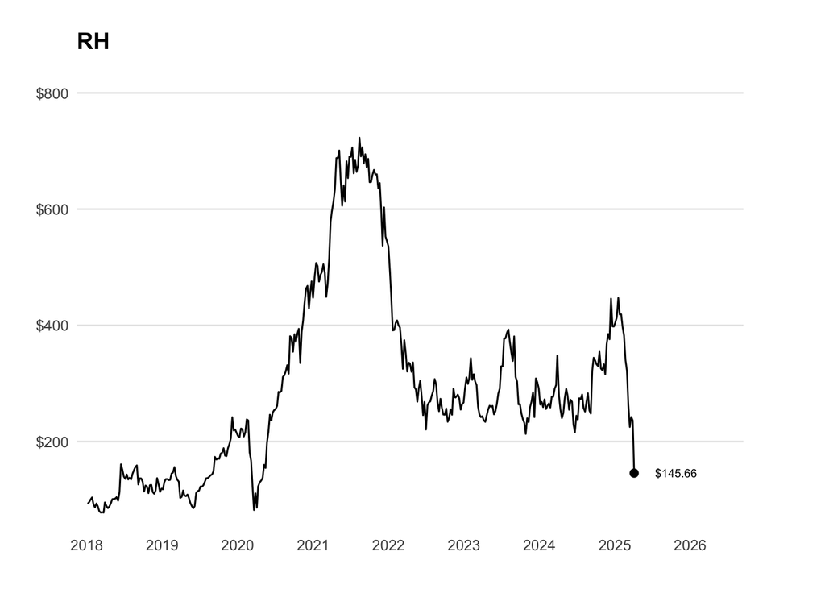

#### Market Cap History

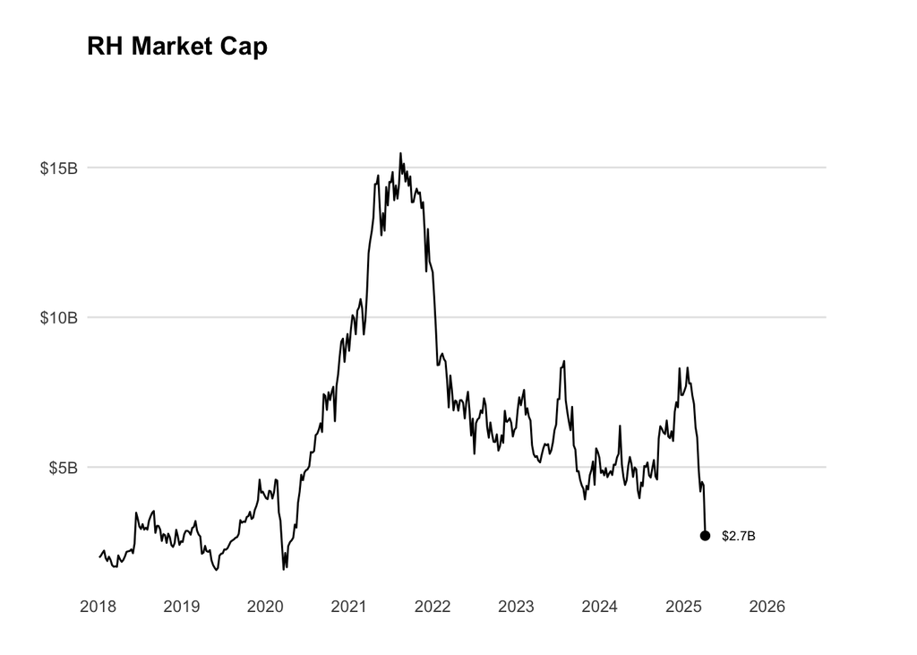

#### Price/EBIT

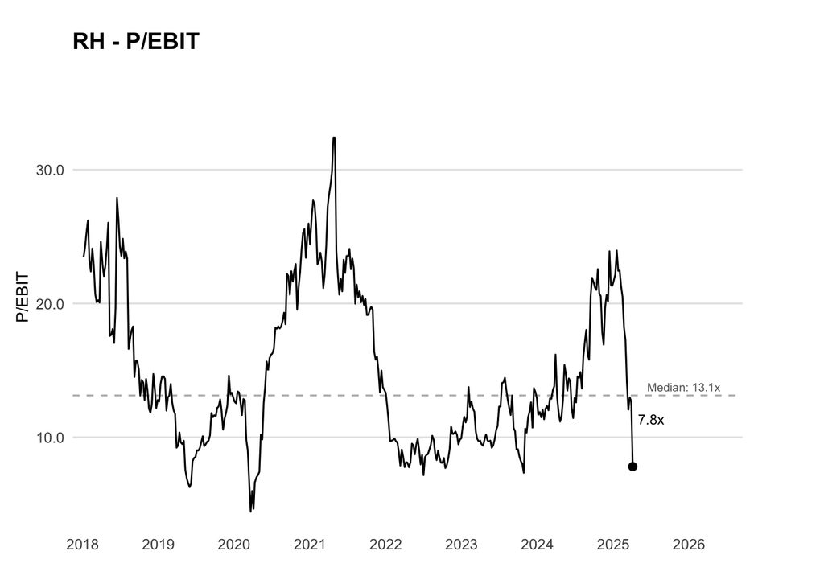

#### EBIT Growth

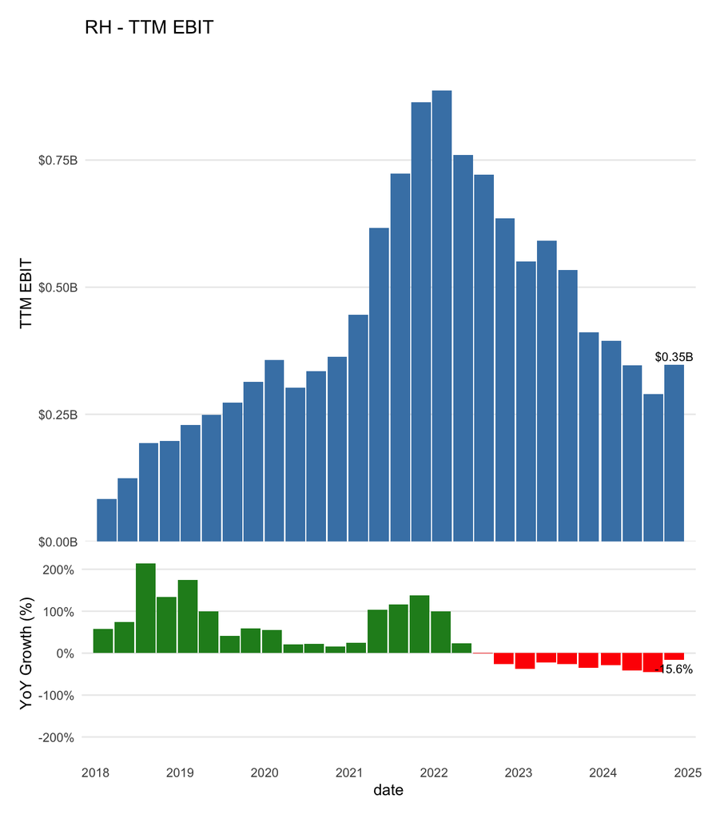

#### Price/Gross Profit

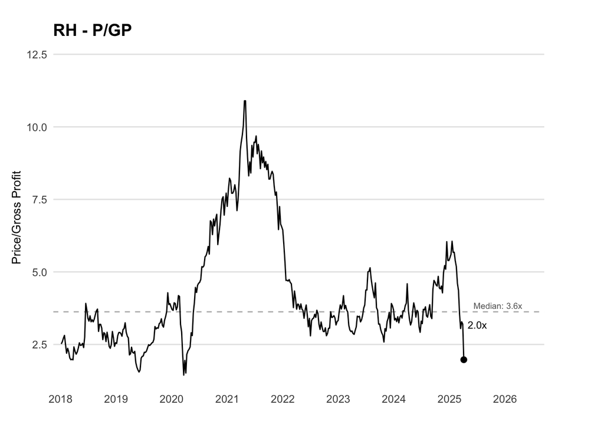

#### Gross Profit Growth

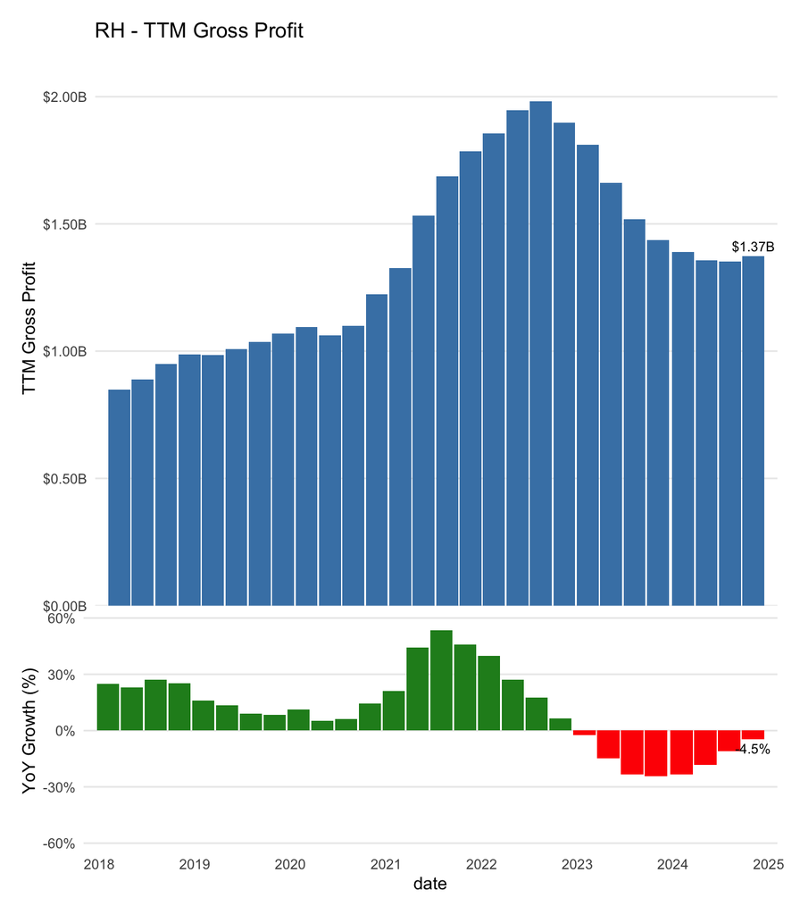

#### Drawdown Analysis

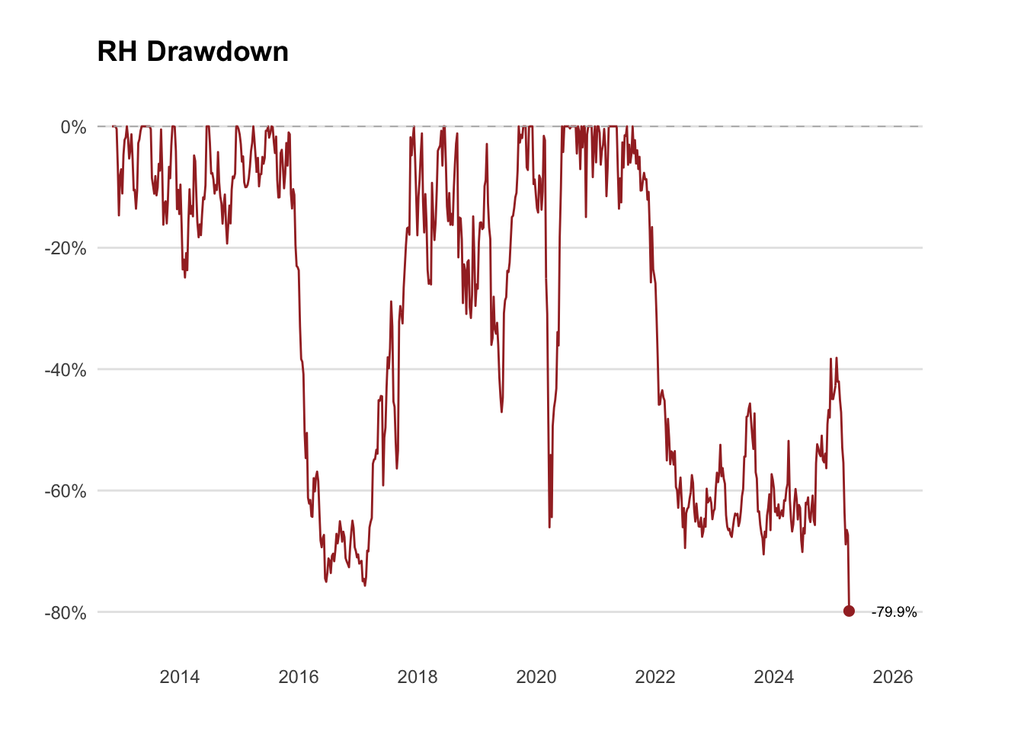

### Metrics

| Market Cap | $2.78B | Revenue TTM | $3.18B | EPS (Diluted) | $3.62 |
| --- | --- | --- | --- | --- | --- |
| P/E (TTM) | 41.27 | Gross Profit | $1.41B | Book Value/Share | -$8.78 |
| Forward P/E | 19.84 | EBITDA | $0.45B | Dividend/Share | NA |
| EV/EBITDA | 18.44 | Operating Margin | 7.41% | Dividend Yield | NA |
| EV/Revenue | 2.708 | Profit Margin | 2.28% | Shares Out. | 19M |
| Price/Sales | 0.874 | ROE | 29.90% | 52-Week High | $457.26 |
| Price/Book | 4.813 | ROA | 4.64% | 52-Week Low | $123.03 |

### Earnings Call Analysis

Here’s an objective analysis of RH’s Q3 2024 key business fundamentals:

Actual Results: - Q3 Revenue: +8.1% YoY - Q3 Adjusted Operating Margin: 15% (vs 7.3% prior year) - Q3 Adjusted EBITDA Margin: 20.8% (vs 12.4% prior year)

Demand Trends: - Q3 demand increased 13% - November demand up 18% - December month-to-date demand up 30% - RH brand specifically saw 24% demand growth in November

Geographic/Segment Performance: - RH England (2nd year): Gallery up 42% Jul-Dec, web business up 111% - RH England projected to reach ~$31M Gallery revenue and $7M web revenue in second full year - Contract, Outlet, Baby & Child, and Teen segments showing slower growth than core RH brand

Development Pipeline: - Opening new galleries in Newport Beach and Montecito in Q4 2024 - 7 North American gallery openings planned for 2025 - 2 International galleries (Paris and London) planned for 2025 - Milan location planned for 2026 - New website functionality planned for Q4 2024 and throughout 2025

Supply Chain Updates: - Actively moving sourcing away from China - Expected full exit from China by end of Q2 2025 - Transitioning production from Mexico - Management claims no expected margin impact from potential 2025 tariff increases

Updated Guidance: Q4 2024: - Demand growth: 20-22% - Revenue growth: 18-20% - Adjusted Operating Margin: 12.2-13.2% - Adjusted EBITDA Margin: 18-19%

Full Year 2024: - Demand growth: 9.9-10.4% - Revenue growth: 6.8-7.2% - Adjusted Operating Margin: 11.5-11.7% - Adjusted EBITDA Margin: 17.2-17.4%

Notable Inconsistencies/Risks: - Q4 guidance appears conservative relative to reported current demand trends - Significant geographic expansion planned despite challenging macro environment - Claims of no tariff impact seem optimistic given scale of required sourcing changes - Core brand significantly outperforming other segments, suggesting potential weakness in diversification strategy

### Analyst Q&A Insights

Here’s my analysis of the Q&A section:

Key Themes in Analyst Questioning:

1. Investment Strategy & Margins
- Analysts focused on whether RH would accelerate investments given their outperformance
- Questions about margin trade-offs for growth
- Concern about balancing growth investments with profitability
2. Housing Market Impact
- Questions about how housing market recovery might affect growth
- Interest in understanding if recent performance can continue/accelerate
- Seeking clarity on relationship between housing market and RH’s performance
3. Guidance vs. Performance
- Questions about conservative Q4 guidance despite strong current trends
- Interest in clearance/markdown strategy impact on margins

Quality of Management Responses:

Strengths: - Detailed explanations of investment philosophy and timing - Clear articulation of strategic rationale for current investments - Transparent about business mix (80% full price vs 20% clearance)

Weaknesses: - Some long, meandering responses that didn’t directly address questions - Heavy use of strategic narrative rather than specific metrics - Tendency to pivot to long-term vision rather than near-term specifics

Notable Skepticism/Concerns:

1. Michael Lasser (UBS) seemed concerned about:
- Sustainability of outperformance
- Margin implications of growth strategy
- Investment pace and returns
2. Christopher Horvers (JPMorgan) focused on:
- Conservative guidance vs actual performance
- Markdown/clearance strategy impact
- Business mix sustainability

Disconnects:

1. Guidance vs. Performance
- Management guiding below current performance trends
- Analysts seeking clarity on conservative outlook despite strong momentum
2. Investment Returns
- Management emphasizing investment benefits
- Analysts probing about concrete returns and margin implications

Overall Assessment: The Q&A reveals a tension between RH’s aggressive growth/investment strategy and analysts’ concerns about sustainability and returns. Management appears confident but analysts seem to want more concrete evidence that the strategy will deliver profitable growth. The questioning suggests some skepticism about the company’s ability to maintain both growth and margins while pursuing their ambitious expansion plans.

The limited number of questions (only two analysts) might indicate either time constraints or a controlled Q&A process, which could be noteworthy in itself.